# linear_practice

Auma

2022-03-14

#SIMPLE LINEAR REGRESSION

## Linear regression is used to predict the value of an outcome variable Y

## based on one or more input predictor variables X.

## The aim is to establish a linear relationship (a mathematical formula)

## between the predictor variable(s) and the response variable,

## so that, we can use this formula to estimate the value of the response Y,

## when only the predictors (Xs) values are known.

### Importing dataset

```r
library(readr)
train <- read_csv("C:/Users/Auma/Desktop/train.csv")
View(train)
```

### Loading ggplot

```r
library(tidyverse)
```

### Check for NA and missing values

### is.na return a vector with value TT for missing values.

```r
numberOfNA = sum(is.na(train))
if(numberOfNA > 0) {
  cat('Number of missing values found: ', numberOfNA)
  cat('\nRemoving missing values...')
  train = train[complete.cases(train), ]
}
```

```
## Number of missing values found:  1
## Removing missing values...
```

## Check for outliers

### Divide the graph area in 2 columns

```r
par(mfrow = c(1, 2))
```

### Boxplot for X

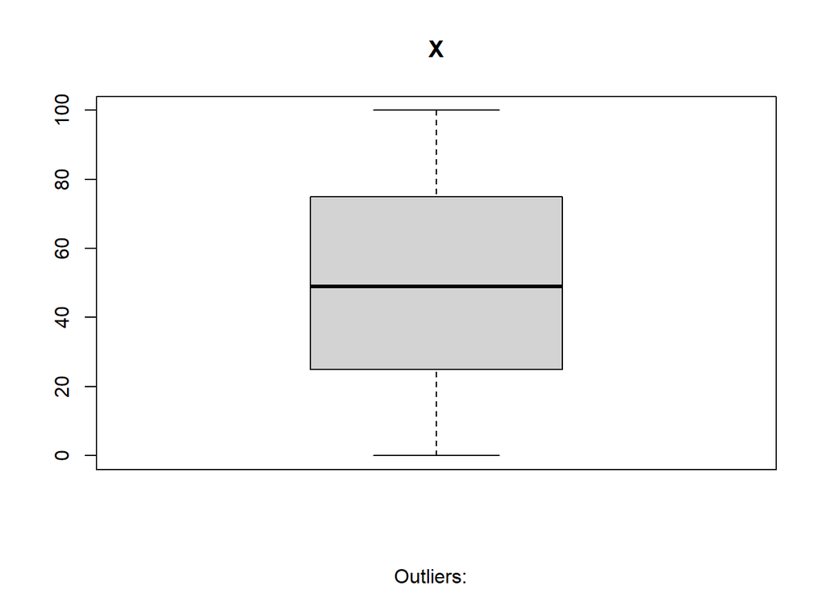

```r
boxplot(train$x, main='X', sub=paste('Outliers: ', boxplot.stats(train$x)$out))
```

### Boxplot for Y

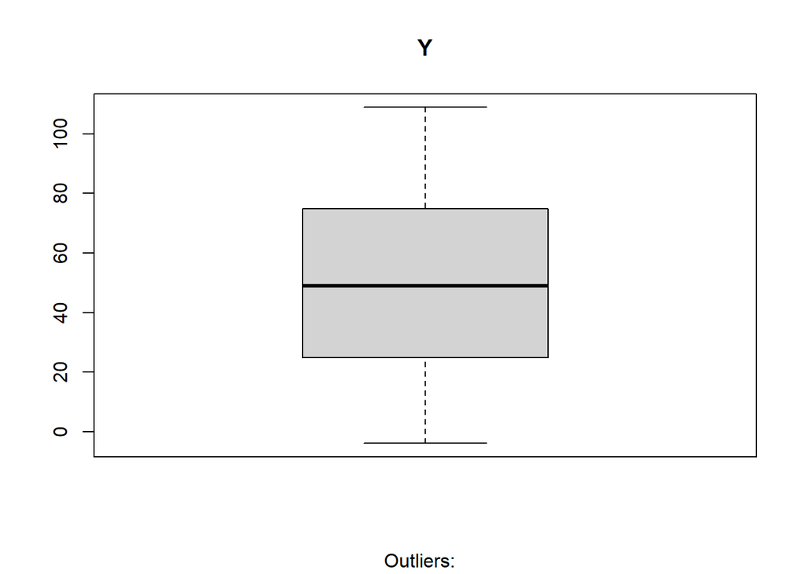

```r
boxplot(train$y, main='Y', sub=paste('Outliers: ', boxplot.stats(train$y)$out))
```

### Both boxplots shows no outliers and distribution is not skewed.

## Finding correlation

### Correlation is a statistical measure that suggests the level of linear dependence between two variables,

### Its value is between -1 to +1

### Above 0 is positive correlation i.e. X is directly proportional to Y.

### Below 0 is negative correlation i.e. X is inversly proportional to Y.

### Value 0 suggests weak relation.

```r
cor(train$x, train$y)
```

```
## [1] 0.9953399
```

### 0.99 shows a very strong relation.

## Fitting Simple Linear regression

### . is used to fit predictor using all independent variables

```r
regressor = lm(formula = y ~.,
               data = train)
```

```r
summary(regressor)
```

```
##
## Call:
## lm(formula = y ~ ., data = train)
##
## Residuals:
##     Min      1Q  Median      3Q     Max
## -9.1523 -2.0179  0.0325  1.8573  8.9132
##
## Coefficients:
##              Estimate Std. Error t value Pr(>|t|)
## (Intercept) -0.107265   0.212170  -0.506    0.613
## x            1.000656   0.003672 272.510   <2e-16 ***
## ---
## Signif. codes:  0 '***' 0.001 '**' 0.01 '*' 0.05 '.' 0.1 ' ' 1
##
## Residual standard error: 2.809 on 697 degrees of freedom
## Multiple R-squared:  0.9907, Adjusted R-squared:  0.9907
## F-statistic: 7.426e+04 on 1 and 697 DF,  p-value: < 2.2e-16
```

### R-Squared tells us is the proportion of variation in the dependent (response) variable that has been explained by this model.

### R square is 0.99 which shows very good variation between dependent variable(y) and independent variable(x).

```r
names(regressor)
```

```
##  [1] "coefficients"  "residuals"     "effects"       "rank"
##  [5] "fitted.values" "assign"        "qr"            "df.residual"
##  [9] "xlevels"       "call"          "terms"         "model"
```

## Visualizing the training set results

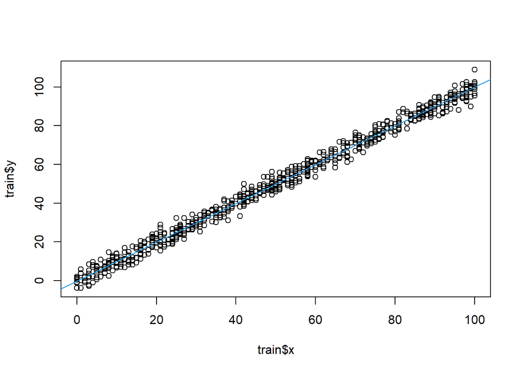

```r
plot(train$x , train$y)
abline(regressor , col=4)
```

### Above plot shows there are no outliers. ### It clearly shows there is a linear relationship between x and y which is continous in nature. ###residual plots to see if the linear regression assumptions are valid or not for the model

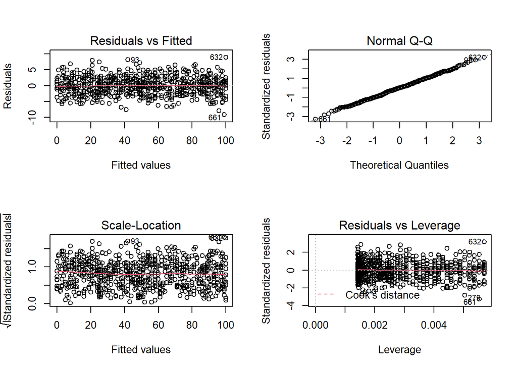

```r
par(mfrow=c(2,2))
plot(regressor)
```

###linear regression assumption are not voilated its a good model. ## Importing test data

```r
library(readr)
test <- read_csv("C:/Users/Auma/Desktop/test.csv")
View(test)
```

## Predicting the test results

```r
pred = predict(regressor, newdata = test)
pred
```

[output not shown]

[output cut: 31 more lines]

[output not shown]

## Visualizing the test set results

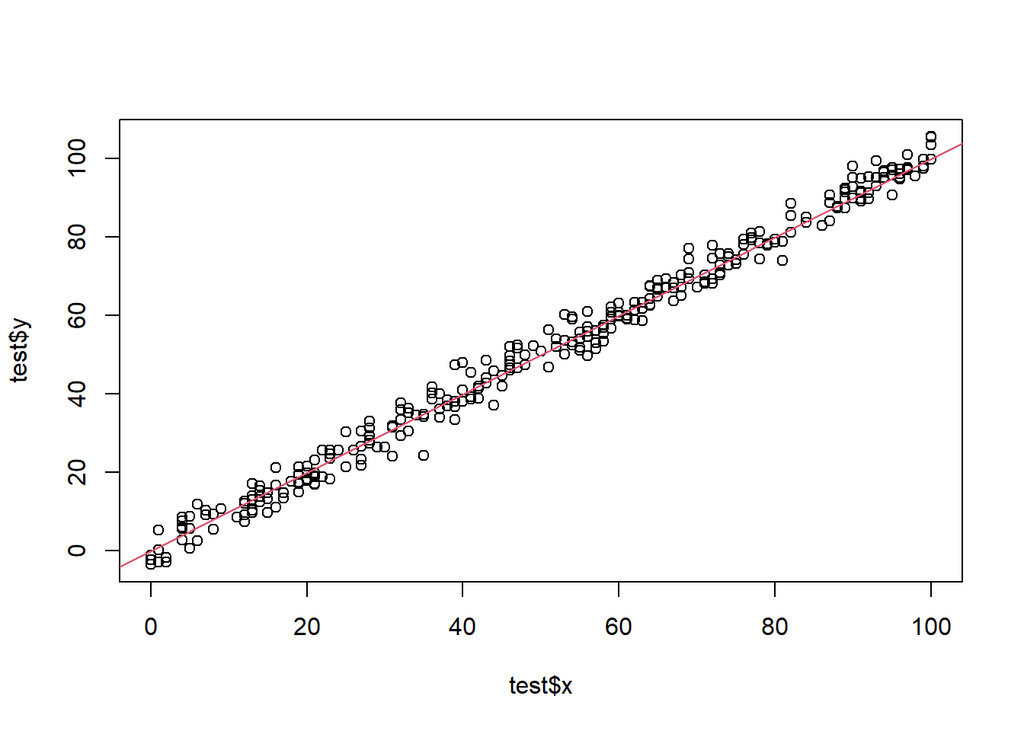

```r
plot(test$x,test$y)
abline(regressor , col=2)
```

### Plot shows model was a good fit.